Universidad El Bosque

Diseño de Experimentos

Sesión 1 de 2 · 90 min

# Cuadros latinos y cuadrados grecolatinos

Dos direcciones de bloqueo: el cuadro, su aleatorización, su modelo, su tabla y cuánto rinde

Cuadro latinoAleatorizaciónAditividadTabla ANOVAEficiencia relativa

**Javier Mauricio Sierra**

Universidad El Bosque

Diseño de Experimentos

Capítulo 6 · Cuadros latinos y cuadrados grecolatinos

Dos direcciones de bloqueo

Construir y aleatorizar

El modelo y el precio de la fracción

La tabla y las cuatro lecturas

Eficiencia relativa

Cierre y práctica

Hoja de ruta

## Lo que vamos a construir hoy

Objetivo de la sesión

Reconocer cuándo hay dos factores perturbadores cruzados, construir y aleatorizar un cuadro latino, leer su tabla ANOVA y medir con la eficiencia relativa cuánto se gana, o se pierde, al bloquear.

Cuadro latinoAleatorizaciónAditividadTabla ANOVAEficiencia relativa

2 / 36

Universidad El Bosque

Diseño de Experimentos

Capítulo 6 · Cuadros latinos y cuadrados grecolatinos

Dos direcciones de bloqueo

Construir y aleatorizar

El modelo y el precio de la fracción

La tabla y las cuatro lecturas

Eficiencia relativa

Cierre y práctica

01

## Dos direcciones de bloqueo

El capítulo 5 tenía un solo enemigo con nombre. Casi siempre hay dos a la vez.

Leer en el material: 6.1 De una a dos direcciones de bloqueo

3 / 36

Dos direcciones de bloqueo

## Un cuadro latino pone cada tratamiento una vez en cada fila y una vez en cada columna

Cuadro latino de orden \(p\)

Un arreglo de \(p \times p\) celdas donde cada uno de \(p\) símbolos aparece **exactamente una vez en cada fila y una vez en cada columna**. Las filas son un factor perturbador, las columnas otro, y las letras son los tratamientos.

Así ningún tratamiento sale favorecido por caer en los días buenos o en manos del operador experto.

Capítulo 6 · Cuadros latinos y cuadrados grecolatinosDiseño de Experimentos · UnBosque4 / 36

Dos direcciones de bloqueo

## En el propelente, cada formulación pasa una vez por cada lote y por cada operador

Cada lote de materia prima alcanza para cinco preparaciones, y los operadores difieren en destreza: dos factores perturbadores cruzados.

|  | Operador 1 | Operador 2 | Operador 3 | Operador 4 | Operador 5 |
| --- | --- | --- | --- | --- | --- |
| Lote 1 | **A** 24 | **B** 20 | **C** 19 | **D** 24 | **E** 24 |
| Lote 2 | **B** 17 | **C** 24 | **D** 30 | **E** 27 | **A** 36 |
| Lote 3 | **C** 18 | **D** 38 | **E** 26 | **A** 27 | **B** 21 |
| Lote 4 | **D** 26 | **E** 31 | **A** 26 | **B** 23 | **C** 22 |
| Lote 5 | **E** 22 | **A** 30 | **B** 20 | **C** 29 | **D** 31 |

Letra: la formulación; número: la velocidad de combustión. Busca la **A**: una vez por fila y una vez por columna.

La pregunta de hoy: ¿difieren las cinco formulaciones una vez descontados el lote y el operador?

Capítulo 6 · Cuadros latinos y cuadrados grecolatinosDiseño de Experimentos · UnBosque5 / 36

Dos direcciones de bloqueo

## El operador se mueve casi tanto como la formulación

La media más alta menos la más baja, en cada factor:

- Entre formulaciones: **9.6**
- Entre operadores: **7.2**
- Entre lotes: **4.6**

El ruido no es despreciable frente a la señal. Si ese movimiento se quedara en el error, el experimento tendría que ser mucho más grande para ver algo.

Capítulo 6 · Cuadros latinos y cuadrados grecolatinosDiseño de Experimentos · UnBosque6 / 36

Dos direcciones de bloqueo

## El cuadro corre 25 de las 125 combinaciones y deja 12 gl para el error

- Factorial formulación × lote × operador: \(p^3 = 125\) corridas
- Cuadro latino: \(p^2 = 25\), **una quinta parte**

Tres factores de \(p - 1\) gl cada uno, sobre \(p^2 - 1\):

$$\text{gl}_E = (p^2-1) - 3(p-1) = (p-1)(p-2)$$

Con \(p = 3\) quedarían 2 gl, y con \(p = 4\), 6: los cuadros pequeños se replican (sesión 2).

| Fuente | gl |
| --- | --- |
| Lotes (filas) | 4 |
| Operadores (columnas) | 4 |
| Formulaciones | 4 |
| Error | 12 |
| Total | 24 |

Capítulo 6 · Cuadros latinos y cuadrados grecolatinosDiseño de Experimentos · UnBosque7 / 36

Pregunta para la clase

## ¿Qué diseño le conviene al laboratorio?

Cuatro métodos de calibración, cuatro técnicos y cuatro días. Los técnicos difieren entre sí y los días también (temperatura, humedad). Cada técnico puede trabajar cualquier día con cualquier método.

1. Un cuadro latino \(4 \times 4\): técnicos en filas, días en columnas y métodos como letras.
2. Un DBCA por técnico, aleatorizando el día dentro de cada técnico.
3. Un DCA de 16 corridas, aleatorizando todo.
4. Un factorial método × técnico × día, con 64 corridas.

1 · El cuadro latino

Hay dos factores perturbadores conocidos, controlables y **cruzados**, con tantos niveles como tratamientos: 16 corridas en vez de 64. El DBCA deja el día dentro del error, y el DCA, los dos.

Capítulo 6 · Cuadros latinos y cuadrados grecolatinosDiseño de Experimentos · UnBosque8 / 36

Idea clave

## El DCA no restringe nada; el DBCA, una dirección; el cuadro latino, dos

Y el grecolatino de la sesión 2, tres. Es la misma idea con distinto número de restricciones.

Capítulo 6 · Cuadros latinos y cuadrados grecolatinosDiseño de Experimentos · UnBosque9 / 36

Universidad El Bosque

Diseño de Experimentos

Capítulo 6 · Cuadros latinos y cuadrados grecolatinos

Dos direcciones de bloqueo

Construir y aleatorizar

El modelo y el precio de la fracción

La tabla y las cuatro lecturas

Eficiencia relativa

Cierre y práctica

02

## Construir y aleatorizar

Un cuadro llenado a mano no es un diseño: se le cuela el sesgo de quien lo llena.

Leer en el material: 6.2 Construir, aleatorizar y contar cuadros

10 / 36

Construir y aleatorizar

## El cuadro cíclico se escribe de memoria: cada fila se corre una posición

El cuadro cíclico

```
ciclico <- function(p) {
  m <- outer(0:(p - 1), 0:(p - 1), function(i, j) (i + j) %% p)
  matrix(LETTERS[m + 1], p, p)
}
ciclico(4)
#>      [,1] [,2] [,3] [,4]
#> [1,] "A"  "B"  "C"  "D"
#> [2,] "B"  "C"  "D"  "A"
#> [3,] "C"  "D"  "A"  "B"
#> [4,] "D"  "A"  "B"  "C"
```

Cuadro estándar

Primera fila y primera columna en orden alfabético; también se llama **reducido**. Todo cuadro se lleva a esa forma permutando filas y columnas, y el cíclico ya está en ella.

El cuadro del propelente es el cíclico de orden 5, tal cual, sin sortear.

Capítulo 6 · Cuadros latinos y cuadrados grecolatinosDiseño de Experimentos · UnBosque11 / 36

Construir y aleatorizar

## Aleatorizar es permutar filas, columnas y letras de un cuadro estándar

La receta del texto guía

```
aleatoriza <- function(M) {
  p <- nrow(M)
  M <- M[sample(p), , drop = FALSE]        # permuta filas
  M <- M[, sample(p), drop = FALSE]        # permuta columnas
  nuevas <- setNames(LETTERS[sample(p)], LETTERS[1:p])
  matrix(nuevas[M], p, p)                  # reasigna letras
}
set.seed(2026)
plan <- aleatoriza(ciclico(5))
plan
#>      [,1] [,2] [,3] [,4] [,5]
#> [1,] "E"  "C"  "D"  "A"  "B"
#> [2,] "C"  "A"  "B"  "D"  "E"
#> [3,] "B"  "E"  "A"  "C"  "D"
#> [4,] "A"  "D"  "E"  "B"  "C"
#> [5,] "D"  "B"  "C"  "E"  "A"
```

- Mover filas enteras, columnas enteras o renombrar letras no rompe «una vez por fila y por columna»: el resultado **sigue siendo latino**
- En el propelente, el sorteo decide qué formulación prepara cada operador con cada lote

Sortear hace improbable que un patrón físico de lotes u operadores coincida con las letras (sección 3).

Capítulo 6 · Cuadros latinos y cuadrados grecolatinosDiseño de Experimentos · UnBosque12 / 36

Pregunta para la clase

## La tabla 4.13 publica 818 851 200 cuadros de orden 6. ¿Cuadra?

El pie de la propia tabla da la fórmula, y hay **9408** cuadros estándar de orden 6:

$$\text{cuadros de orden } p = p!\,(p-1)! \times (\text{estándar de orden } p)$$

Cada cuadro estándar da \(p!\) cuadros al reordenar sus columnas y \((p-1)!\) al reordenar las filas bajo la primera.

No: son 812 851 200

\(720 \times 120 \times 9408 = 812\,851\,200\). Seis millones de diferencia: una sola cifra, un 8 donde va un 2. La fila del \(7 \times 7\) sí cumple la fórmula. **Cuando una tabla trae su propia fórmula, se comprueba.**

Capítulo 6 · Cuadros latinos y cuadrados grecolatinosDiseño de Experimentos · UnBosque13 / 36

Construir y aleatorizar

## Del cíclico \(4 \times 4\), la receta solo alcanza 432 de los 576 cuadros

- Hay \((4!)^3 = 13\,824\) maneras de permutar filas, columnas y letras, pero cada cuadro sale 32 veces: \(13\,824 / 32 = 432\)
- Eso es la **órbita** del cíclico. Los **144** que nunca salen son justo los que se pueden ampliar a grecolatino (sesión 2)
- Con \(p = 5\) alcanza 17 280 de 161 280, un 10.7 %, pero ahí todos los que alcanza se pueden ampliar

Para analizar, cualquiera de los 432 sirve. Pero «aleatorizado» no es «elegido al azar entre todos los cuadros», y la diferencia pesa si el cuadro se va a ampliar.

Capítulo 6 · Cuadros latinos y cuadrados grecolatinosDiseño de Experimentos · UnBosque14 / 36

Universidad El Bosque

Diseño de Experimentos

Capítulo 6 · Cuadros latinos y cuadrados grecolatinos

Dos direcciones de bloqueo

Construir y aleatorizar

El modelo y el precio de la fracción

La tabla y las cuatro lecturas

Eficiencia relativa

Cierre y práctica

03

## El modelo y el precio de la fracción

El cuadro corre una quinta parte del factorial. Lo que no corre, no lo puede estimar.

Leer en el material: 6.3 El modelo, sus supuestos y el precio de la fracción

15 / 36

El modelo y el precio de la fracción

## El modelo suma un efecto de fila, uno de columna y uno de tratamiento; nada más

$$y_{ijk} = \mu + \alpha_i + \tau_j + \beta_k + \varepsilon_{ijk}$$

- \(\alpha_i\): el lote (fila); \(\beta_k\): el operador (columna); \(\tau_j\): la formulación
- Los índices recorren solo las \(p^2\) celdas del cuadro: fijadas la fila y la columna, la letra ya está decidida
- La hipótesis que interesa: \(H_0: \tau_1 = \dots = \tau_p = 0\)

Ese «nada más» es un supuesto: el modelo no tiene términos de interacción. Se llama **aditividad**, y es lo que esta sección pone a prueba.

Capítulo 6 · Cuadros latinos y cuadrados grecolatinosDiseño de Experimentos · UnBosque16 / 36

El modelo y el precio de la fracción

## Lo que el cuadro llama «error» es un trozo de las interacciones

$$\underbrace{(p-1)(p-2)}_{\text{gl del «error» del cuadro}} \;\text{de los}\; \underbrace{3(p-1)^2 + (p-1)^3}_{\text{gl de interacción del factorial}}$$

Con \(p = 5\): 12 de 112. El cuadro no tiene sitio para las interacciones: si existen, se confunden con el error o con los efectos.

Sin interacción, ese trozo estima \(\sigma^2\). **La aditividad es la condición para que el error sea error.**

Capítulo 6 · Cuadros latinos y cuadrados grecolatinosDiseño de Experimentos · UnBosque17 / 36

El modelo y el precio de la fracción

## En el cuadro cíclico, la letra *es* \((i + k) \bmod p\)

|  | 0 | 1 | 2 | 3 | 4 |
| --- | --- | --- | --- | --- | --- |
| **0** | A | B | C | D | E |
| **1** | B | C | D | E | A |
| **2** | C | D | E | A | B |
| **3** | D | E | A | B | C |
| **4** | E | A | B | C | D |

|  | 0 | 1 | 2 | 3 | 4 |
| --- | --- | --- | --- | --- | --- |
| **0** | 0 | 1 | 2 | 3 | 4 |
| **1** | 1 | 2 | 3 | 4 | 0 |
| **2** | 2 | 3 | 4 | 0 | 1 |
| **3** | 3 | 4 | 0 | 1 | 2 |
| **4** | 4 | 0 | 1 | 2 | 3 |

Con A = 0, B = 1…, las dos tablas son la misma.

Una deriva física que siga ese patrón se atribuye **entera** al tratamiento, y nada en los datos lo delata.

Capítulo 6 · Cuadros latinos y cuadrados grecolatinosDiseño de Experimentos · UnBosque18 / 36

El modelo y el precio de la fracción

## Con la interacción alineada, la tasa de rechazo sube hasta 1 sin ningún efecto real

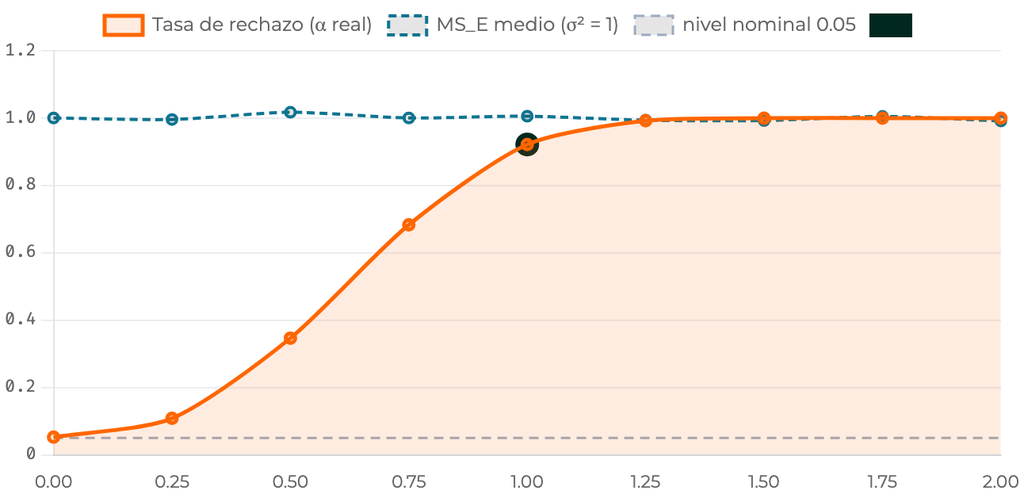

Tasa de rechazo de H0 y MS_E medio frente a la magnitud de la interacción fila × columna, sin efecto de tratamiento (patrón alineado)

Eje horizontal: el tamaño de la interacción. **Naranja**: la tasa de rechazo sin ningún efecto real. **Azul**: el \(MS_E\) medio, quieto, porque la interacción no cae en el error: **cae entera en el tratamiento**.

Capítulo 6 · Cuadros latinos y cuadrados grecolatinosDiseño de Experimentos · UnBosque19 / 36

El modelo y el precio de la fracción

## Fabricar significación y destruirla son el mismo fallo

### Interacción alineada

Sigue el patrón \((i + k) \bmod p\) de las letras y queda confundida al 100 % con el tratamiento. Sin ningún \(\tau_j\) distinto de cero, la tasa de rechazo sube a **1.000**.

### Interacción multiplicativa

Una tendencia de fila por una de columna. El 74 % cae dentro del error y lo infla **7.3 veces**; la tasa de rechazo baja de 0.052 a **0.001**.

Una inventa un efecto que no existe; la otra esconde los que existen. En los dos casos, la prueba \(F\) deja de decir lo que dice.

Capítulo 6 · Cuadros latinos y cuadrados grecolatinosDiseño de Experimentos · UnBosque20 / 36

Pregunta para la clase

## Sobre la aditividad del cuadro latino, ¿cuáles son correctas?

1. El cuadro es una fracción \(1/p\) del factorial \(p^3\): no puede estimar ninguna interacción.
2. Una interacción alineada con el patrón del cuadro puede hacer significativo un tratamiento que no hace nada.
3. Una interacción multiplicativa infla el \(MS_E\) y hace la prueba menos potente.
4. Si la prueba de Tukey del capítulo 5 no rechaza, el cuadro queda libre de toda no aditividad.

1, 2 y 3

La 4 no: la prueba de Tukey cabe en el cuadro gastando un gl del error, pero solo busca una forma concreta de no aditividad. La alineada se confunde con el tratamiento y ninguna prueba la ve: la defensa es de diseño.

Capítulo 6 · Cuadros latinos y cuadrados grecolatinosDiseño de Experimentos · UnBosque21 / 36

Universidad El Bosque

Diseño de Experimentos

Capítulo 6 · Cuadros latinos y cuadrados grecolatinos

Dos direcciones de bloqueo

Construir y aleatorizar

El modelo y el precio de la fracción

La tabla y las cuatro lecturas

Eficiencia relativa

Cierre y práctica

04

## La tabla y las cuatro lecturas

Los mismos veinticinco números, analizados cuatro veces.

Leer en el material: 6.4 Descomposición, tabla ANOVA y las cuatro lecturas

22 / 36

La tabla y las cuatro lecturas

## La suma de cuadrados se parte en cuatro: \(676 = 68 + 150 + 330 + 128\)

$$SS_T = SS_{\text{Filas}} + SS_{\text{Columnas}} + SS_{\text{Trat}} + SS_E$$

Cada suma se calcula como en el DBCA, con una dirección de bloqueo más, y las cuatro cierran exactas porque el diseño es ortogonal.

Los operadores (**150**) se llevan más del doble que los lotes (**68**): es el trozo de ruido que el segundo bloqueo saca del error.

Capítulo 6 · Cuadros latinos y cuadrados grecolatinosDiseño de Experimentos · UnBosque23 / 36

La tabla y las cuatro lecturas

## Las formulaciones difieren: \(F_0 = 7.73\) contra un crítico de 3.26

ANOVA del cuadro latino

```
mod <- aov(y ~ lote + operador + formula,
           data = propelente)
summary(mod)
#>             Df Sum Sq Mean Sq F value  Pr(>F)
#> lote         4     68   17.00   1.594 0.23906
#> operador     4    150   37.50   3.516 0.04037 *
#> formula      4    330   82.50   7.734 0.00254 **
#> Residuals   12    128   10.67
```

- \(p = 0.0025\), con 4 y 12 gl
- \(R^2 = 0.811\) y \(\sqrt{MS_E} = 3.27\)
- Las \(F\) de lotes y operadores **se leen, no se prueban**: la aleatorización se restringió en esas direcciones

Se rechaza \(H_0\): al menos una formulación difiere. Cuáles, en la sesión 2.

Capítulo 6 · Cuadros latinos y cuadrados grecolatinosDiseño de Experimentos · UnBosque24 / 36

Pregunta para la clase

## ¿Cuánto vale el cuadrado medio del error?

En un cuadro latino \(5 \times 5\): \(SS_T = 206.64\), \(SS_{\text{Trat}} = 141.44\), \(SS_{\text{Filas}} = 15.44\) y \(SS_{\text{Columnas}} = 12.24\).

3.1267

\(SS_E = 206.64 - 141.44 - 15.44 - 12.24 = 37.52\), y se divide entre \((p-1)(p-2) = 12\), no entre \(N - p = 20\).

Capítulo 6 · Cuadros latinos y cuadrados grecolatinosDiseño de Experimentos · UnBosque25 / 36

La tabla y las cuatro lecturas

## Mismos datos, cuatro modelos: \(SS_{\text{Trat}} = 330\) en todos

| Lectura | \(SS_E\) | gl | \(MS_E\) | \(F_0\) | \(p\) |
| --- | --- | --- | --- | --- | --- |
| DCA | 346 | 20 | 17.300 | 4.769 | 0.0073 |
| DBCA por lotes | 278 | 16 | 17.375 | 4.748 | 0.0102 |
| DBCA por operadores | 196 | 16 | 12.250 | 6.735 | 0.0022 |
| Cuadro latino | 128 | 12 | 10.667 | 7.734 | 0.0025 |

El \(SS_E\) cae de 346 a 128, a menos de la mitad; los gl solo bajan de 20 a 12. Por eso el \(MS_E\) baja y el \(F\) sube: bloquear compensa cuando el error cae más deprisa que sus gl.

Capítulo 6 · Cuadros latinos y cuadrados grecolatinosDiseño de Experimentos · UnBosque26 / 36

Pregunta para la clase

## Bloquear por lotes deja el error peor que no bloquear. ¿Cómo es posible?

DCA: \(MS_E = 17.300\). DBCA por lotes: \(MS_E = 17.375\). Los lotes se llevan \(SS = 68\) con 4 grados de libertad.

Los lotes absorben menos por grado de libertad que el error

\(68/4 = 17\), menos que los 17.300 del error. El modelo gasta cuatro grados de libertad y no compra nada. **Bloquear por el factor equivocado sale peor que no bloquear, aunque sea por poco.**

Capítulo 6 · Cuadros latinos y cuadrados grecolatinosDiseño de Experimentos · UnBosque27 / 36

Universidad El Bosque

Diseño de Experimentos

Capítulo 6 · Cuadros latinos y cuadrados grecolatinos

Dos direcciones de bloqueo

Construir y aleatorizar

El modelo y el precio de la fracción

La tabla y las cuatro lecturas

Eficiencia relativa

Cierre y práctica

05

## Eficiencia relativa

«El cuadro latino es mejor» no dice nada hasta que se dice cuánto.

Leer en el material: 6.5 Eficiencia relativa: lo que el cuadro gana y lo que cuesta

28 / 36

Eficiencia relativa

## La eficiencia relativa compara el error del cuadro con el que habría dado un DCA

$$\hat\sigma^2_{\text{DCA}} = \frac{MS_{\text{Filas}} + MS_{\text{Col}} + (p-1)MS_E}{p+1}$$

El error que habría medido un DCA con el mismo material, con filas y columnas de vuelta en él.

$$R = \frac{(f_1+1)(f_2+3)}{(f_1+3)(f_2+1)} \cdot \frac{\hat\sigma^2_{\text{DCA}}}{MS_E}$$

\(f_1 = 12\) y \(f_2 = 20\) son los gl del error del cuadro y del DCA. La corrección, siempre menor que 1, cobra los gl gastados en bloquear.

\(R\) dice cuántas veces más corridas necesitaría un DCA para igualar la precisión del cuadro: por encima de 1, bloquear ganó; por debajo, perdió.

Capítulo 6 · Cuadros latinos y cuadrados grecolatinosDiseño de Experimentos · UnBosque29 / 36

Eficiencia relativa

## Frente a un DCA, el cuadro latino rinde 1.44; sin la corrección parecería 1.52

Con los cuadrados medios del propelente (lotes 17.0, operadores 37.5, error 10.667):

$$\hat\sigma^2_{\text{DCA}} = \frac{17.0 + 37.5 + 4(10.667)}{6} = 16.194$$

$$R = 0.949 \times \frac{16.194}{10.667} = 0.949 \times 1.518 = 1.441$$

- La corrección, 0.949, le quita un 5 % a la razón: es el precio de los 8 gl gastados en bloquear
- Frente al DBCA por lotes sale 1.456: la ganancia viene del operador

Un DCA necesitaría un **44 %** más de corridas para igualar esta precisión: aquí bloquear ganó.

Capítulo 6 · Cuadros latinos y cuadrados grecolatinosDiseño de Experimentos · UnBosque30 / 36

Pregunta para la clase

## Con efectos de bloqueo nulos, ¿por qué \(R\) sale por debajo de 1?

Eficiencia relativa frente al DCA cuando los efectos de fila y de columna valen **cero**:

| Cuadro | \(4 \times 4\) | \(5 \times 5\) | \(7 \times 7\) |
| --- | --- | --- | --- |
| \(R\) | 0.8974 | 0.9492 | 0.9831 |

Bloquear sin necesidad cuesta grados de libertad

Con efectos nulos solo queda la corrección, siempre menor que 1. El cuadro gasta \(2(p-1)\) gl del error, que pesan menos cuanto mayor es \(p\): **bloquear por si acaso es caro en cuadros pequeños y casi gratis en grandes.**

Capítulo 6 · Cuadros latinos y cuadrados grecolatinosDiseño de Experimentos · UnBosque31 / 36

Eficiencia relativa

## En los ingredientes, bloquear en dos direcciones salió perdiendo: \(R = 0.983\)

Los datos de la pregunta del \(MS_E\): cinco ingredientes y el tiempo de reacción de un proceso químico, con lotes en filas y días en columnas. La misma cuenta:

$$\hat\sigma^2_{\text{DCA}} = \frac{3.86 + 3.06 + 4(3.127)}{6} = 3.238$$

$$R = 0.949 \times \frac{3.238}{3.127} = 0.949 \times 1.036 = 0.983$$

- Lotes y días absorben por gl casi lo mismo que el error: \(F\) de 1.235 y 0.979
- La ganancia bruta, 1.036, no alcanza a pagar la corrección por los **8 de 24** gl gastados

Un DCA habría dado la misma precisión con un 1.7 % menos de corridas. El análisis sigue siendo válido: se perdió precisión, no validez.

Capítulo 6 · Cuadros latinos y cuadrados grecolatinosDiseño de Experimentos · UnBosque32 / 36

Idea clave

## Bloquear es una apuesta, y como toda apuesta se puede perder

Se gana cuando el bloqueo absorbe más variación por grado de libertad de la que ya tenía el error.

Capítulo 6 · Cuadros latinos y cuadrados grecolatinosDiseño de Experimentos · UnBosque33 / 36

Universidad El Bosque

Diseño de Experimentos

Capítulo 6 · Cuadros latinos y cuadrados grecolatinos

Dos direcciones de bloqueo

Construir y aleatorizar

El modelo y el precio de la fracción

La tabla y las cuatro lecturas

Eficiencia relativa

Cierre y práctica

06

## Cierre y práctica

Leer en el material: 6.12 Resumen, autoevaluación y lecturas

34 / 36

Cierre y práctica

## Lo que se llevan hoy

- Cada tratamiento, una vez en cada fila y una vez en cada columna: dos bloqueos con \(p^2\) corridas
- Aleatorizar es permutar filas, columnas y letras, aunque así no se sortea entre todos los cuadros
- El cuadro es una fracción: exige **aditividad**, y sin ella fabrica o destruye significación
- En el propelente, el \(MS_E\) baja de 17.30 a 10.67 y el \(F\) sube de 4.77 a 7.73
- Bloquear es una apuesta, y la eficiencia relativa dice si se ganó

Javier Mauricio Sierra

Capítulo 6 · Cuadros latinos y cuadrados grecolatinosDiseño de Experimentos · UnBosque35 / 36

Cierre y práctica

## Práctica en R: EG-21, cinco ingredientes en un cuadro latino

|  | Día 1 | Día 2 | Día 3 | Día 4 | Día 5 |
| --- | --- | --- | --- | --- | --- |
| Lote 1 | A 8 | B 7 | D 1 | C 7 | E 3 |
| Lote 2 | C 11 | E 2 | A 7 | D 3 | B 8 |
| Lote 3 | B 4 | A 9 | C 10 | E 1 | D 5 |
| Lote 4 | D 6 | C 8 | E 6 | B 6 | A 10 |
| Lote 5 | E 4 | D 2 | B 3 | A 8 | C 8 |

- **(a)** Analízalo con \(\alpha = 0.05\): el \(MS_E\) debe dar 3.1267
- **(b)** Reproduce con código el \(R = 0.983\): ¿hacía falta bloquear en las dos direcciones?
- Unos 15 min, con el `ingr` del módulo 6.7. El (c) y el (d) van en la sesión 2

Capítulo 6 · Cuadros latinos y cuadrados grecolatinosDiseño de Experimentos · UnBosque36 / 36

[output not shown]

·

A continuación

Notas